# Fundamentos de Probabilidade, Análise Exploratória de Dados e Visualização de Dados com ggplot2

Exercícios das Aulas e Soluções

Autor

Prof. Dr. Washington S. da Silva

Data de Publicação

13/06/2024

# Introdução

**Conteúdo e Objetivo**

Este arquivo contém todos os exercícios e respectivas soluções sobre os tópicos os seguintes módulos da disciplina Introdução à Ciência de Dados:

- Módulo 4: **Fundamentos de Probabilidade**;
- Módulo 5: **Análise Exploratória de Dados**, e;
- Módulo 6: **Visualização de Dados com ggplot2**.

O objetivo é disponibilizar um material organizado para estudo e consulta para a **Avaliação 2**.

# Tópico: Tipos de Variáveis Aleatórias

## Exercício 1

### Identificando Variáveis Aleatórias em Contextos Empresariais

Para cada uma das situações abaixo, identifique a variável aleatória descrita, classifique-a como **discreta** ou **contínua**:

1. O número mensal de cancelamentos de assinaturas em uma plataforma de streaming
2. O tempo de entrega (em horas) para pedidos online de uma loja de e-commerce
3. A variação percentual diária no preço das ações de uma empresa
4. O número de unidades vendidas de um novo produto no primeiro mês após seu lançamento

## Solução do Exercício 1

1. Variável Aleatória **Discreta**. O número de cancelamentos só pode assumir valores inteiros não-negativos $(0, 1, 2, 3, ...)$.
2. Variável Aleatória **Contínua**. O tempo é uma grandeza que pode assumir qualquer valor real positivo dentro de um intervalo.
3. Variável Aleatória **Contínua**. A variação percentual pode assumir qualquer valor real dentro de um intervalo
4. Variável Aleatória **Discreta**. O número de unidades vendidas só pode assumir valores inteiros não-negativos $(0, 1, 2, 3, ...)$.

# Tópico: Score Padronizado e Análise Relativa

## Exercício 2

### Aplicação de Score Padronizado

**Situação**: Após uma avaliação, você deseja fornecer aos alunos uma análise do desempenho relativo de cada um em relação à turma.

**Dados da avaliação:**

- **Média da turma**: 55 pontos (de 100)
- **Desvio padrão**: 12 pontos
- **Amplitude**: notas de 38 a 85 pontos

**Objetivo**: Utilizar o score padronizado para:

1. Mostrar a posição relativa de cada aluno
2. Calcular o percentil de cada aluno
3. Facilitar a interpretação do desempenho individual
- Simula as notas de cada aluno para o exemplo

```r
# Simulando notas de uma turma de 19 alunos
# Fixa a semente para reprodutibilidade
set.seed(2024)

# Simula notas com média 55 e desvio padrão 12
notas_turma <- round(rnorm(19, mean = 55, sd = 12))

# Limita as notas entre 38 e 85
notas_turma <- pmax(38, pmin(85, notas_turma))

# Visualiza as notas simuladas
head(notas_turma, 19)
```

```
 [1] 67 61 54 52 69 71 61 53 40 42 38 61 65 59 38 53 44 60 38
```

## Solução do Exercício 2

### Aplicação de Score Padronizado

- Cálculo das Notas Relativas

```r
# Cria a data frame analise_relativa
analise_relativa <- data.frame(alunos = 1:19, notas = notas_turma) %>%
  # Calcula o z-score e nota relativa
  mutate(
    z_score = scale(notas),              # calcula o z-score
    z_score_arred = round(z_score, 1),   # arredonda o z-score
    nota_relativa = round(pnorm(z_score) * 100, 1)  # percentil
  ) %>%
  # Remove coluna intermediária
  select(-z_score)

# Visualiza os dados
head(analise_relativa, 19)
```

```
   alunos notas z_score_arred nota_relativa
1       1    67           1.2          87.9
2       2    61           0.6          73.5
3       3    54           0.0          50.0
4       4    52          -0.2          42.9
5       5    69           1.3          91.1
6       6    71           1.5          93.7
7       7    61           0.6          73.5
8       8    53          -0.1          46.4
9       9    40          -1.3          10.4
10     10    42          -1.1          14.0
11     11    38          -1.4           7.5
12     12    61           0.6          73.5
13     13    65           1.0          83.9
14     14    59           0.4          67.4
15     15    38          -1.4           7.5
16     16    53          -0.1          46.4
17     17    44          -0.9          18.4
18     18    60           0.5          70.5
19     19    38          -1.4           7.5
```

- **Interpretação da análise relativa**

**Colunas da tabela:**

- **notas**: Nota original do aluno (0-100)
- **z_score_arred**: Quantos desvios-padrão acima/abaixo da média
  - Valores negativos: abaixo da média da turma
  - Valores positivos: acima da média da turma
- **nota_relativa**: Percentil do aluno na turma (0-100)
  - Interpretação: “Este aluno superou X% dos colegas”

**Exemplos de interpretação:**

- Aluno 6 (nota 71): z = 1.5, percentil 93.7
  - Está 1.5 desvios-padrão acima da média
  - Nota superior a 93.7% das notas da turma
- Aluno 11 (nota 38): z = -1.4, percentil 7.5
  - Está 1.4 desvios-padrão abaixo da média
  - Apenas 7.5% dos colegas tiveram nota inferior

**Vantagem**: A função `pnorm()` converte automaticamente cada z-score no percentil correspondente

# Tópico: Distribuição Normal

## Exercício 3

### Análise de Investimentos

**Cenário**: A distribuição dos retornos mensais de uma ação segue aproximadamente uma distribuição normal com média de 1% e desvio-padrão de 3% ($R \sim N(\mu = 0.01, \sigma = 0.03)$).

1. Qual a probabilidade de sofrer uma perda mensal superior a 4%? Ou seja, encontre $P(R < -0.04)$.
2. Qual a probabilidade de obter um retorno positivo no próximo mês? Ou seja, encontre $P(R > 0)$.
3. Qual a probabilidade de obter um retorno superior a 5%? Ou seja, encontre $P(R > 0.05)$.

## Solução do Exercício 3

### Análise de Investimentos

```r
# Calcula P(R < - 0.04)
pnorm(-0.04, mean = 0.01, sd = 0.03)
```

```
[1] 0.04779
```

2. Qual a probabilidade de obter um retorno positivo no próximo mês? Ou seja encontre $P(R > 0)$.

```r
# Calcula P(R > 0)
1 - pnorm(0, mean = 0.01, sd = 0.03)
```

```
[1] 0.63056
```

3. Qual a probabilidade de obter um retorno superior a 5%? Ou seja, encontre $P(R > 0.05)$.

```r
# Calcula P(R > 0.05)
1 - pnorm(0.05, mean = 0.01, sd = 0.03)
```

```
[1] 0.091211
```

## Exercício 4

### Vendas e Previsão de Estoque

**Cenário**: As vendas diárias de um produto seguem distribuição normal com média de R$ 12.000 e desvio-padrão de R$ 2.500 ($V \sim N(\mu = 12000, \sigma = 2500)$).

1. Qual a probabilidade de que em um dia as vendas excedam R$ 15.000? Ou seja, encontre $P(V > 15000)$.
2. Para garantir estoque em 95% dos dias, qual deveria ser o valor mínimo de vendas para preparação? Encontre $y$ tal que $P(V < y) = 0.95$.
3. Qual o valor mínimo de vendas esperado com 90% de probabilidade? Encontre $x$ tal que $P(V > x) = 0.90$.

## Solução do Exercício 4

### Vendas e Previsão de Estoque

1. Qual a probabilidade de que em um determinado dia as vendas excedam R$ 15.000? Ou seja, encontre $P(V > 15000)$.

```r
# Calcula P(V > 15000) = 1 - P(V < 15000)
1 - pnorm(15000, mean = 12000, sd = 2500)
```

```
[1] 0.11507
```

2. Encontre o valor $y$ tal que $P(V < y) = 0.95$.

```r
# Calcula o valor y tal que P(V < y) = 0.95
qnorm(0.95, mean = 12000, sd = 2500)
```

```
[1] 16112
```

3. Encontre o valor $x$ tal que $P(V > x) = 0.90$.

```r
# Calcula o valor x tal que P(V > x) = 0.90
# Isso é equivalente ao percentil 10
qnorm(0.10, mean = 12000, sd = 2500)
```

```
[1] 8796.1
```

# Tópico: Valor Esperado

## Exercício 5

### Aplicação do Valor Esperado em Seguros

**Contexto**: Seguradora oferece proteção contra incêndios residenciais

**Dados históricos:**

- Probabilidade anual de incêndio de uma casa: 1% (0.01)
- Indenização média por incêndio: R$ 150.000
- Margem desejada: 25%

**Perguntas:**

1. Calcule o valor esperado de indenizações por residência
2. Determine o prêmio anual a ser cobrado
3. Implemente a solução em R

## Solução do Exercício 5

### Aplicação do Valor Esperado em Seguros

```r
# Definir os parâmetros
prob_incendio <- 0.01
valor_indenizacao <- 150000
margem <- 0.25

# a) Valor esperado das indenizações
valor_esperado <- prob_incendio * valor_indenizacao
valor_esperado
```

```
[1] 1500
```

```r
# b) Prêmio anual com margem
premio_anual <- valor_esperado * (1 + margem)
premio_anual
```

```
[1] 1875
```

```r
# c) Simulação para verificar
set.seed(123)
n_casas <- 10000
sinistros <- sample(c(0, valor_indenizacao), n_casas,
                   prob = c(0.99, 0.01), replace = TRUE)

# Calcula a média dos sinistros
media_sinistros <- mean(sinistros)
media_sinistros
```

```
[1] 1515
```

```r
# Calcula o número de incêndios
num_incendios <- sum(sinistros > 0)
num_incendios
```

```
[1] 101
```

# Tópico: Análise de Risco e Coeficiente de Variação

## Exercício 6

### Análise de Risco de Investimentos

**Cenário**: Um gestor de investimentos está comparando dois fundos com diferentes perfis de risco.

**Dados Calculados**:

- **Fundo Conservador**: Retorno esperado = 8.6%, Desvio-padrão = 1.9%
- **Fundo Arrojado**: Retorno esperado = 10.2%, Desvio-padrão = 6.9%

**Perguntas**:

1. Calcule o coeficiente de variação para cada fundo.
2. Compare o risco relativo dos dois fundos.
3. Qual fundo você recomendaria para um investidor conservador? Justifique.

## Solução do Exercício 6

### Análise de Risco de Investimentos

```r
# Cálculo dos Coeficientes de Variação (CV)

cv_fundo_conservador <- (1.9 / 8.6) * 100
cv_fundo_conservador
```

```
[1] 22.093
```

```r
cv_fundo_arrojado <- (6.9 / 10.2) * 100
cv_fundo_arrojado
```

```
[1] 67.647
```

**Interpretação:**

Apesar do fundo arrojado ter um retorno esperado maior, seu coeficiente de variação (CV) é significativamente maior, indicando que o risco relativo é muito mais alto, cerca de 3 vezes ($67/22 \approx 3$) maior que o risco do fundo conservador.

## Exercício 7

### Gestão de Estoque

**Cenário**: Uma loja está comparando a previsibilidade da demanda de dois produtos.

**Dados**:

- **Produto A**: Demanda Esperada = E(D) = $\mu$ = 100 unidades, $\sigma$ = 15 unidades
- **Produto B**: Demanda Esperada = E(D) = $\mu$ = 50 unidades, $\sigma$ = 12 unidades

**Perguntas**:

1. Calcule o coeficiente de variação para cada produto.
2. Qual produto tem maior risco relativo de demanda?
3. Qual seria mais desafiador para gerenciar estoque?

## Solução do Exercício 7

### Gestão de Estoque

```r
# Cálculo dos Coeficientes de Variação (CV)

cv_a <- (15 / 100) * 100
cv_a
```

```
[1] 15
```

```r
cv_b <- (12 / 50) * 100
cv_b
```

```
[1] 24
```

**Interpretação:**

Como o coeficiente de variação da demanda do produto b é maior que o do produto a, isso indica que o produto b tem uma maior variabilidade (risco) relativa do que a do produto a,assim, é mais desafiador gerenciar o estoque do produto b.

# Tópico: Valor-em-Risco (VaR)

## Exercício 8

### Valor-em-Risco (VaR)

Você está analisando um portfólio de títulos governamentais com:

- Retorno médio mensal: 0.8%
- Volatilidade mensal: 3.2%
- Valor investido: US$ 250.000

Considerando que os retornos do protfólio seguem aproximadamente uma distribuição normal:

- Calcule o VaR mensal de 95% (percentual e monetário)
- Calcule o VaR mensal de 99% (percentual e monetário)
- Compare os resultados e interprete a diferença

**Dica**: Use `qnorm()` no R para obter os quantis da distribuição normal.

## Solução do Exercício 8

### Valor-em-Risco (VaR)

```r
# Parâmetros do investimento
retorno_medio <- 0.008     # 0.8%
volatilidade <- 0.032      # 3.2%
valor <- 250000            # US$ 250k

# 1. VaR 95% percentual e monetário
var_95_percentual <- retorno_medio + qnorm(0.05) * volatilidade
var_95_percentual
```

```
[1] -0.044635
```

```r
var_95_monetário <- valor * var_95_percentual
var_95_monetário
```

```
[1] -11159
```

```r
# 2. VaR 99% percentual e monetário
var_99_percentual <- retorno_medio + qnorm(0.01) * volatilidade
var_99_percentual
```

```
[1] -0.066443
```

```r
var_99_monetário <- valor * var_99_percentual
var_99_monetário
```

```
[1] -16611
```

**Interpretação:**

**VaR Mensal a 95%:**

- **Percentual**: -4.46%  
  Significa que há 5% de probabilidade de o portfólio perder mais que 4.46% em um mês.
- **Monetário**: US$ 11.159  
  Representa a perda máxima esperada com 95% de confiança para o investimento de US$ 250.000.

**VaR Mensal a 99%:**

- **Percentual**: -6.64%  
  Indica que há apenas 1% de chance de perdas superiores a 6.64% no mês.
- **Monetário**: US$ 16.611  
  Mostra a perda máxima esperada com 99% de confiança.

**Comparação:**

- O VaR a 99% é maior (em valor absoluto) que o VaR a 95%, como esperado  
  → Quanto maior o nível de confiança, maior a perda potencial extrema
- A diferença reflete o trade-off entre:
  - **Confiança estatística** (99% vs 95%)
  - **Magnitude da perda potencial** (maior no 99%)
- O VaR negativo indica perda potencial (retorno abaixo da média)

*Observação*: Esses cálculos assumem distribuição normal dos retornos, o que pode subestimar riscos em eventos extremos.

# Tópico: Covariância e Correlação entre Variáveis Aleatórias

## Exercício 9

### Covariação entre os retornos de duas ações

**Cenário**: Um investidor está analisando a correlação entre os retornos de duas ações para construir um portfólio diversificado. Os retornos mensais históricos (em %) das duas ações nos últimos 6 meses foram:

| Mês | Ação A | Ação B |
| --- | --- | --- |
| 1 | 2.5 | 1.8 |
| 2 | -1.2 | 3.1 |
| 3 | 4.1 | -0.5 |
| 4 | 1.8 | 2.4 |
| 5 | -0.8 | 1.2 |
| 6 | 3.6 | -1.0 |

**Perguntas**:

1. Faça um gráfico de dispersão dos retornos das duas ações. Analisando o gráfico, você considera que há alguma correlação entre os retornos das duas ações? Se sim, qual?
2. Calcule a covariância e o coeficiente de correlação entre as duas ações.
3. Com base na correlação, essas ações são uma boa opção para diversificação? Explique.

## Solução do Exercício 9

### Gráfico de Dispersão e Interpretação

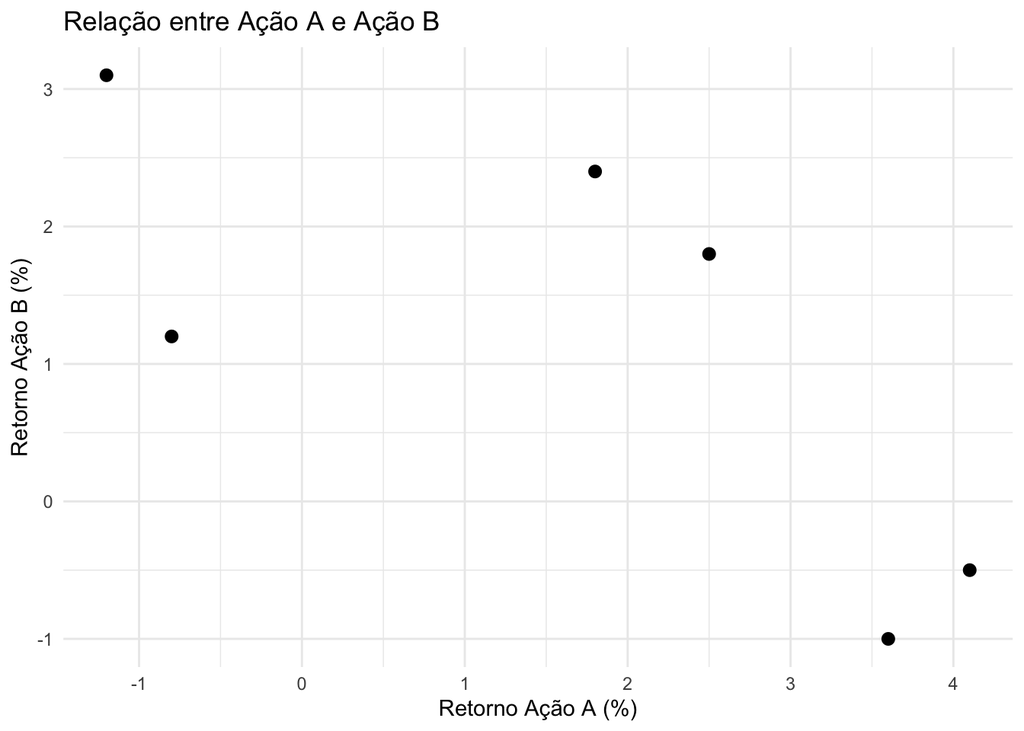

**Interpretação de Gráfico de Dispersão:**

Analisando o gráfico de dispersão, parece haver uma correlação negativa forte entre os retornos das ações A e B, indicando que quando uma ação tem um retorno positivo, a outra tende a ter um retorno negativo, e vice-versa.

### Cálculo da Covariância e Correlação

```r
# Cálculo da covariância
covariancia <- cov(acao_a, acao_b)
covariancia
```

```
[1] -2.6353
```

```r
# Cálculo correlação
correlacao <- cor(acao_a, acao_b)
correlacao
```

```
[1] -0.73199
```

# Tópico: Simulação de Monte Carlo

## Exercício 10

### Simulacão de Monte Carlo - Análise de Viabilidade de Projeto de Investimento

**Cenário**: Uma startup de tecnologia está avaliando o lançamento de um novo aplicativo. A receita líquida do primeiro ano depende de fatores como aceitação do mercado e concorrência. Os possíveis cenários são:

- **Fracasso**: Receita líquida de -R$ 100.000 (probabilidade 30%)
- **Sucesso Moderado**: Receita líquida de R$ 200.000 (probabilidade 50%)
- **Grande Sucesso**: Receita líquida de R$ 500.000 (probabilidade 20%)

**Perguntas**:

1. Use simulação de Monte Carlo com 10.000 repetições para estimar a receita líquida esperada.
2. Qual a probabilidade de a empresa ter receita líquida positiva no primeiro ano?
3. Qual a probabilidade de a receita líquida superar R$ 300.000?

## Solução do Exercício 10

```r
# Definir cenários e probabilidades
receitas <- c(-100000, 200000, 500000)
probabilidades <- c(0.30, 0.50, 0.20)

# Função de simulação
simulacao_receita <- function() {
  sample(receitas, size = 1, prob = probabilidades, replace = TRUE)
}

# Simulação de Monte Carlo com 10.000 repetições

# fixa a semente para reprodutibilidade
set.seed(123)
simulacoes <- 10000
receitas_simuladas <- replicate(simulacoes, simulacao_receita())

# 1. Receita liquida esperada
receita_esperada <- mean(receitas_simuladas)
receita_esperada
```

```
[1] 168650
```

```r
# 2. Probabilidade de receita positiva
prob_positiva <- mean(receitas_simuladas > 0)
prob_positiva
```

```
[1] 0.7006
```

```r
# 3. Probabilidade de superar R$ 300.000
prob_300k <- mean(receitas_simuladas > 300000)
prob_300k
```

```
[1] 0.1949
```

## Exercício 11

### Gestão de Riscos Operacionais

**Cenário**: Uma transportadora precisa avaliar os custos extras mensais devido a problemas operacionais (acidentes, multas, manutenção não programada). Historicamente, os custos extras seguem este padrão:

- **Mês Tranquilo**: Custo extra de R$ 5.000 (probabilidade 40%)
- **Mês Normal**: Custo extra de R$ 15.000 (probabilidade 35%)
- **Mês Problemático**: Custo extra de R$ 35.000 (probabilidade 20%)
- **Mês Crítico**: Custo extra de R$ 60.000 (probabilidade 5%)

**Perguntas**:

1. Use simulação de Monte Carlo com 15.000 repetições para estimar o custo extra médio mensal.
2. Qual a probabilidade de os custos extras mensais excederem R$ 25.000?
3. Para fins de planejamento orçamentário, qual valor a empresa deveria reservar mensalmente para cobrir custos extras em 90% dos casos?

## Solução do Exercício 11

```r
# Definir cenários e probabilidades
custos_extras <- c(5000, 15000, 35000, 60000)
probabilidades <- c(0.40, 0.35, 0.20, 0.05)

# Função de simulação
simulacao_custos <- function() {
  sample(custos_extras, size = 1, prob = probabilidades, replace = TRUE)
}

# 1. Simulação de Monte Carlo com 15.000 repetições
set.seed(456)
simulacoes <- 15000
custos_simulados <- replicate(simulacoes, simulacao_custos())

# Custo extra médio mensal
custo_extra_medio <- mean(custos_simulados)
custo_extra_medio
```

```
[1] 17399
```

```r
# Verificação teórica
custo_teorico <- sum(custos_extras * probabilidades)
custo_teorico
```

```
[1] 17250
```

```r
# 2. Probabilidade de exceder R$ 25.000
prob_25k <- mean(custos_simulados > 25000)
prob_25k
```

```
[1] 0.25407
```

```r
# 3. Valor para cobertura de 90% dos casos
percentil_90 <- quantile(custos_simulados, 0.90)
percentil_90
```

```
  90%
35000
```

# Tópico: Análise Exploratória de Dados Numérica

## Exercício 12

### Medidas de Posição

Considere o seguinte conjunto de dados que representa as idades de clientes em uma loja:

```r
idades <- c(23, 25, 28, 28, 32, 35, 36, 38, 40, 42, 45, 47, 50, 52, 55, 60, 65)
```

1. Calcule a idade média dos clientes
2. Determine a idade mediana e compare com a idade média
3. Encontre o primeiro e terceiro quartis
4. Identifique o percentil 90
5. Verifique se há moda nos dados

**Discussão**: O que as medidas de posição revelam sobre a distribuição das idades?

## Solução do Exercício 12

Para resolver este exercício, precisamos da função `calcular_moda()` elaborada durante a aula:

```r
# Função simples para calcular a moda de um vetor numérico
calcular_moda <- function(x) {
  # 1. Cria tabela de frequências
  tab <- table(x)

  # 2. Identifica valor(es) com máxima frequência
  moda <- as.numeric(names(tab)[tab == max(tab)])

  # 3. Retorna o resultado
  return(moda)
}
```

Estimativa da idade média:

```r
mean(idades)
```

```
[1] 41.235
```

Estimativa da idade mediana:

```r
median(idades)
```

```
[1] 40
```

Estimando os quartis:

```r
quantile(idades, probs = c(0.25, 0.5, 0.75))
```

```
25% 50% 75%
 32  40  50
```

Estimando os percentis 10, 30, 40, 80 e 90:

```r
quantile(idades, probs = c(0.1, 0.3, 0.4, 0.8, 0.9))
```

```
 10%  30%  40%  80%  90%
26.8 34.4 36.8 51.6 57.0
```

Estimando a moda:

```r
# 5. Moda
calcular_moda(idades)
```

```
[1] 28
```

**Interpretação**:

- A média (41.23529) e mediana (40) são próximas, sugerindo distribuição simétrica
- O primeiro quartil (32) indica que 25% dos clientes têm até esta idade
- O percentil 90 (57) indica que 90% dos clientes têm até esta idade
- moda = 28 (idade mais frequente entre os clientes)

## Exercício 13

### Medidas de Variabilidade

Uma empresa de tecnologia está analisando o desempenho (em R$ mil) de duas equipes de vendas em 2023:

```r
# Metodologia tradicional de vendas
equipe_A <- c(85, 92, 78, 110, 95, 105, 115, 98, 102, 250)
equipe_A
```

```
 [1]  85  92  78 110  95 105 115  98 102 250
```

```r
# Nova metodologia de vendas
equipe_B <- c(120, 115, 125, 118, 122, 130, 115, 120, 125, 122)
equipe_B
```

```
 [1] 120 115 125 118 122 130 115 120 125 122
```

1. Calcule para cada equipe:
   - Variância e desvio-padrão
   - Amplitude e IQR
   - Coeficiente de variação
2. Compare os resultados e responda:
   - Qual equipe tem desempenho mais consistente?
   - O outlier na Equipe A afeta quais medidas?
   - Se você fosse o gestor, qual métrica usaria para avaliar a equipe mais estável?

**Contexto**: A Equipe B utiliza uma nova metodologia de vendas

## Solução do Exercício 13

Para resolver este exercício, precisamos da função `cv()` elabordada durante a aula:

```r
cv <- function(x, na.rm = FALSE) {

  # 1. tratamento de valores ausentes (NAs)
  if(na.rm) x <- x[!is.na(x)]

  # 2. Verifica se o vetor está vazio
  # após a remoção de NAs
  if(length(x) == 0) return(NA)

  # 3. Cálculo do desvio padrão:
  desvio <- sd(x, na.rm = na.rm)

  # 4. Cálculo da média:
  media <- mean(x, na.rm = na.rm)

  # 5. Cálculo final do CV:
  (desvio / media) * 100
}
```

```r
# cria df para exibir resultados
data.frame(
  Medida = c("Variância", "Desvio-Padrão", "Amplitude", "IQR", "CV"),
  Valor = c(round(var(equipe_A), 2),
           round(sd(equipe_A), 2),
           diff(range(equipe_A)),
           IQR(equipe_A),
           paste0(round(cv(equipe_A), 2), "%"))
)
```

```
         Medida   Valor
1     Variância 2440.67
2 Desvio-Padrão    49.4
3     Amplitude     172
4           IQR      16
5            CV  43.72%
```

- **Equipe B:**

```r
# cria df para exibir resultados
data.frame(
  Medida = c("Variância", "Desvio-Padrão", "Amplitude", "IQR", "CV"),
  Valor = c(round(var(equipe_B), 2),
           round(sd(equipe_B), 2),
           diff(range(equipe_B)),
           IQR(equipe_B),
           paste0(round(cv(equipe_B), 2), "%"))
)
```

```
         Medida Valor
1     Variância 21.96
2 Desvio-Padrão  4.69
3     Amplitude    15
4           IQR  5.75
5            CV 3.87%
```

**Análise Gerencial**:

1. **Consistência**: Equipe B tem menor CV (3.87% vs 43.72%), indicando maior estabilidade no desempenho.
2. **Impacto do Outlier**: Afeta fortemente a variância, o desvio-padrão,  
   a amplitude e o cv, tornando essas medidas menos representativas.
3. **Métrica Recomendada**: IQR, por ser robusta a valores extremos.
4. **Tomada de Decisão**: A nova metodologia (Equipe B) produz resultados mais previsíveis.

## Exercício 14

### Medidas de Correlação

Uma empresa de consultoria deseja entender a relação entre diferentes métricas de performance de seus consultores. Os dados abaixo representam 12 consultores selecionados aleatoriamente:

```r
# Dados reais de uma empresa de consultoria
dados_consultoria <- data.frame(
  consultor = 1:12,
  horas_treinamento = c(20, 35, 15, 40, 25, 10, 30, 45, 18, 28, 38, 22),
  satisfacao_cliente = c(7.2, 8.5, 6.8, 9.1, 7.8, 6.2, 8.2, 9.3, 7.0, 8.0, 8.8, 7.5),
  faturamento_mensal = c(45, 68, 38, 85, 52, 32, 62, 92, 42, 58, 75, 48)
)

# Exibir primeiras linhas
head(dados_consultoria, 5)
```

```
  consultor horas_treinamento satisfacao_cliente faturamento_mensal
1         1                20                7.2                 45
2         2                35                8.5                 68
3         3                15                6.8                 38
4         4                40                9.1                 85
5         5                25                7.8                 52
```

**Tarefas**:

1. Crie uma matriz de gráficos de dispersão (scatterplot matrix) para visualizar todas as relações simultaneamente.
2. Calcule e interprete a matriz de correlação completa.
3. Identifique qual relação é mais forte e discuta as implicações gerenciais.
4. A empresa planeja investir R$ 50.000 em treinamento. Com base na análise, este investimento se justifica? Explique.
5. **Reflexão crítica**: Se encontrarmos alta correlação entre treinamento e faturamento, podemos afirmar que treinar mais causará maior faturamento? Justifique.

## Solução do Exercício 14

1. Visualização das Relações

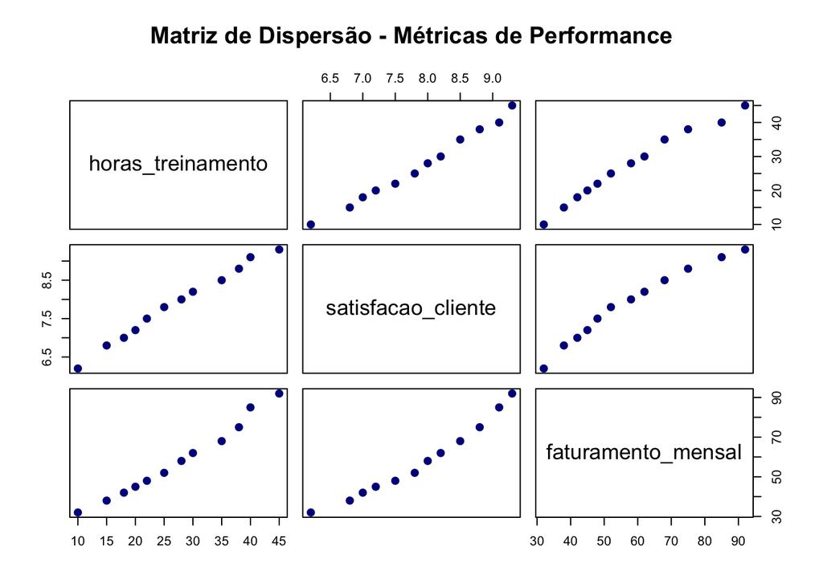

```r
# Matriz de gráficos de dispersão
pairs(dados_consultoria[, -1],
      main = "Matriz de Dispersão - Métricas de Performance",
      pch = 19,
      col = "darkblue",
      cex = 1.2)
```

2. Matriz de Correlação

```r
# Calcula correlações
matriz_cor <- cor(dados_consultoria[, -1])
round(matriz_cor, 3)
```

```
                   horas_treinamento satisfacao_cliente faturamento_mensal
horas_treinamento              1.000              0.995              0.991
satisfacao_cliente             0.995              1.000              0.982
faturamento_mensal             0.991              0.982              1.000
```

3. Análise das Relações

```r
# Correlação entre horas de treinamento e faturamento
cor_treinamento_faturamento <- cor(dados_consultoria$horas_treinamento,
                                   dados_consultoria$faturamento_mensal)
# exibir correlação
cor_treinamento_faturamento
```

```
[1] 0.9907
```

```r
# Correlação entre horas de treinamento e satisfação do cliente
cor_treinamento_satisfacao <- cor(dados_consultoria$horas_treinamento,
                                  dados_consultoria$satisfacao_cliente)
# exibir correlação
cor_treinamento_satisfacao
```

```
[1] 0.99536
```

**Interpretação**:

- Ambas as correlações são **positivas** e **fortes**:
  - 0.991 entre horas de treinamento e faturamento mensal
  - 0.995 entre horas de treinamento e satisfação do cliente
- Correlação **muito forte e positiva**: consultores com mais horas de treinamento tendem a gerar maior faturamento
- A satisfação do cliente também está positivamente correlacionada com ambas as métricas

**4. Decisão de Investimento**

Com base na correlação de 0.991:

- **Recomendação**: O investimento em treinamento se justifica, pois consultores mais treinados tendem a gerar maior faturamento e satisfação do cliente, pelas estimativas dos coeficientes de correlação.

**5. Reflexão sobre Causalidade**

**ATENÇÃO**: Correlação $\neq$ Causalidade!

Possíveis explicações alternativas:

- **Seleção**: Consultores mais motivados buscam mais treinamento E trabalham mais
- **Confundimento**: Consultores seniores têm acesso a mais treinamento E clientes maiores
- **Causalidade reversa**: Alto faturamento permite investir em mais treinamento

**Conclusão**: Para estabelecer causalidade, seria necessário um experimento controlado ou análise mais sofisticada.

# Tópico: Análise Exploratória de Dados Gráfica

## Exercício 15

### Visualizando a Ditribuição de Variáveis Numéricas

- Prática com ggplot2 usando a data frame `diamonds`

**Parte 1 - Crie os seguintes gráficos para visualizar a variável `price`**

- Histograma (use `bins = 30`)
- Gráfico de densidade empírica
- Histograma + densidade sobreposta
- Boxplot

**Parte 2 - Análise descritiva**

- Analise o histograma + densidade da Parte 1
- Siga as diretrizes apresentadas em aula
- Comente sobre forma, centro, dispersão e outliers

**Parte 3 - Análise comparativa**

- Crie boxplots de `price` por `clarity`
- Aplique transformação log10 para melhor visualização
- Compare os padrões entre as categorias

**Requisitos:**

- Todos os gráficos devem ter títulos e rótulos apropriados
- Customização visual é opcional (exploratório vs. publicação)

**Dica:** A distribuição de `price` é assimétrica. Experimente visualizar também `log10(price)` para comparar interpretações nas duas escalas.

## Solução do Exercício 15

### **Parte 1 - Visualizando a distribuição da variável** `price`

1. Histograma

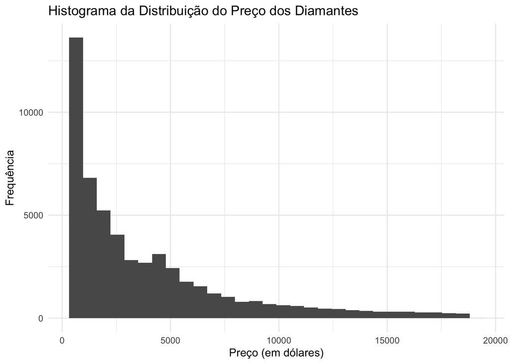

```r
# Histograma com regra de Sturges
ggplot(diamonds, aes(x = price)) +
  geom_histogram(bins = 30) +
  labs(title = "Histograma da Distribuição do Preço dos Diamantes",
       x = "Preço (em dólares)",
       y = "Frequência") +
  theme_minimal()
```

2. Gráfico de densidade empírica

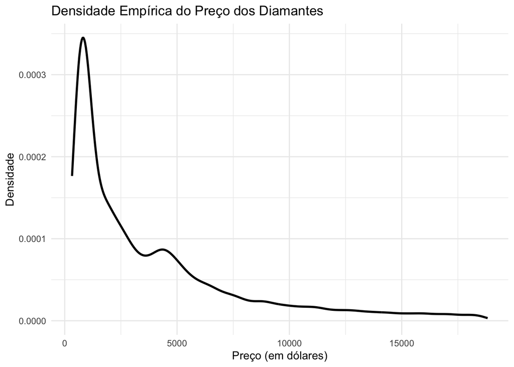

```r
# Gráfico de densidade empírica
ggplot(diamonds, aes(x = price)) +
    geom_density(size = 1) +
  labs(title = "Densidade Empírica do Preço dos Diamantes",
       x = "Preço (em dólares)",
       y = "Densidade") +
  theme_minimal()
```

3. Histograma + densidade sobreposta

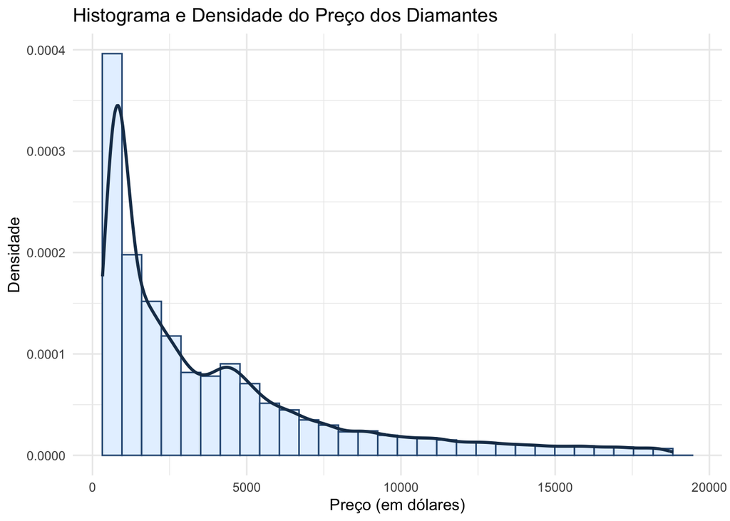

```r
# Histograma + densidade sobreposta
ggplot(diamonds, aes(x = price)) +
  geom_histogram(
    aes(y = after_stat(density)), # normaliza o histograma
    bins = 30,
    fill = "#E6F2FF", # azul muito claro para as barras
    color = "#2E5984" # azul escuro para borda das barras
  ) +
  geom_density(color = "#1B3A57", size = 1) +
  labs(
    title = "Histograma e Densidade do Preço dos Diamantes",
    x = "Preço (em dólares)",
    y = "Densidade"
  ) +
  theme_minimal()
```

4. Boxplot

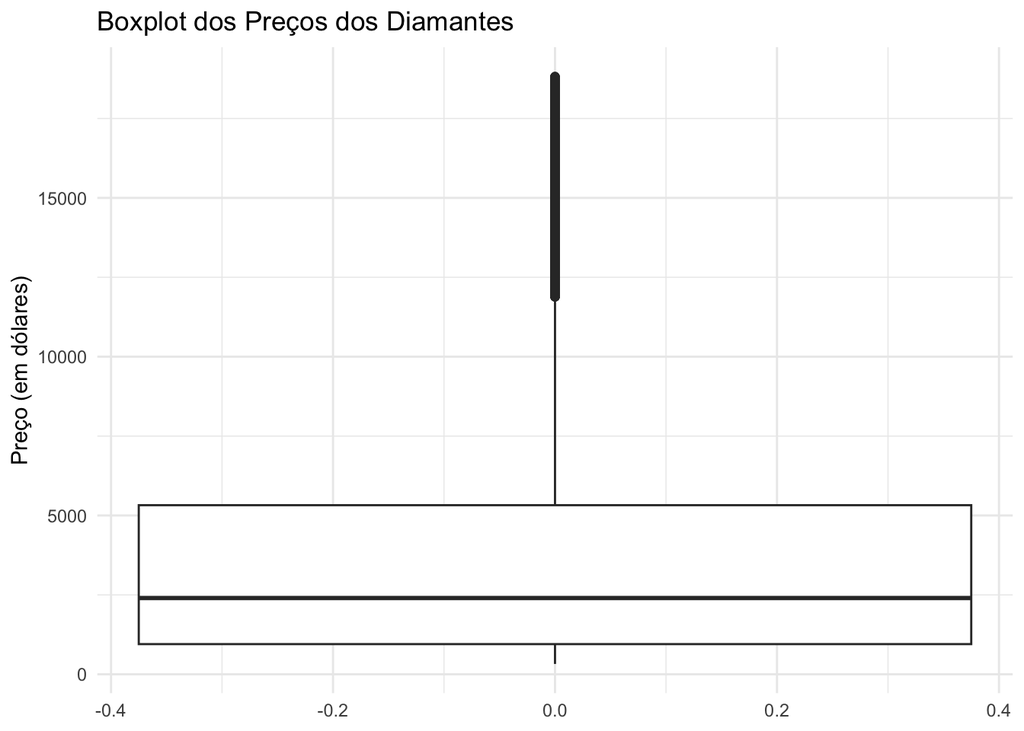

```r
# Boxplot dos preços dos diamantes
ggplot(diamonds, aes(y = price)) +
  geom_boxplot() +
  labs(title = "Boxplot dos Preços dos Diamantes",
       y = "Preço (em dólares)") +
  theme_minimal()
```

### **Parte 2 - Análise descritiva do histograma da distribuição de `price`**

Como visto em aula, para analisar variáveis numéricas, devemos combinar as estatísticas descritivas calculadas com a visualização gráfica. Assim, vamos caluclar algumas medidas de posição e de variabilidade do preço dos diamantes, e depois analisar o histograma com densidade sobreposta.

A função `summary` fornece medidas de posição para a variável price (mínimo, máximo, média, mediana, primeiro e terceiro quartis):

```r
summary(diamonds$price)
```

```
   Min. 1st Qu.  Median    Mean 3rd Qu.    Max.
    326     950    2401    3933    5324   18823
```

Agora, vamos cálcular os coeficientes de assimetria e curtose:

```r
assimetria_preco <- moments::skewness(diamonds$price)
assimetria_preco
```

```
[1] 1.6184
```

```r
curtose_preco <- moments::kurtosis(diamonds$price)
curtose_preco
```

```
[1] 5.1774
```

### **Parte 3 - Análise comparativa de `price` por `clarity`**

1. Boxplots de `price` por `clarity`

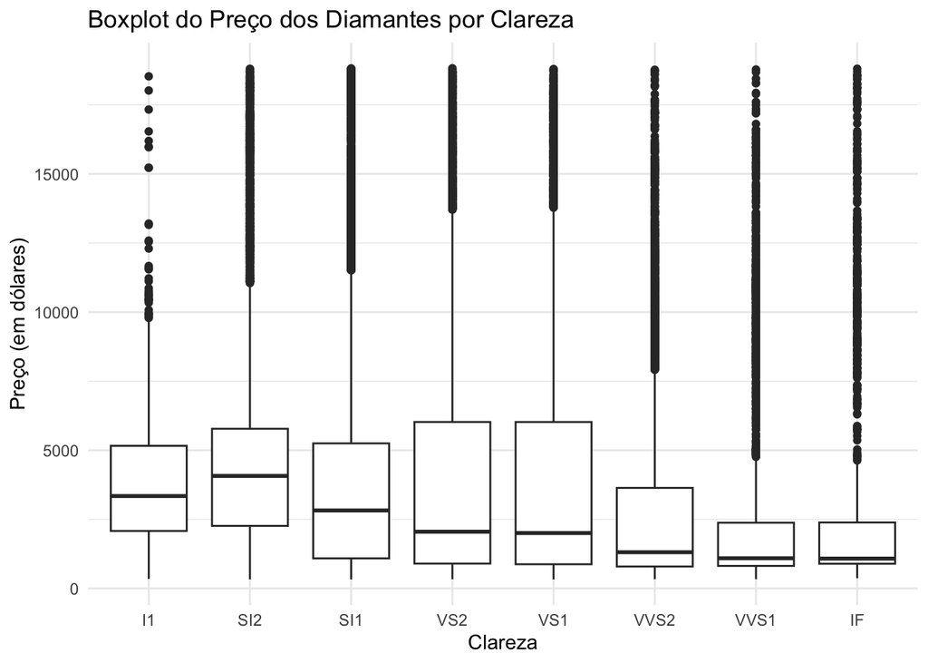

```r
# Boxplot de price por clarity
ggplot(diamonds, aes(x = clarity, y = price)) +
  geom_boxplot() +
  labs(title = "Boxplot do Preço dos Diamantes por Clareza",
       x = "Clareza",
       y = "Preço (em dólares)") +
  theme_minimal()
```

2. Aplicando transformação log10 para melhor visualização

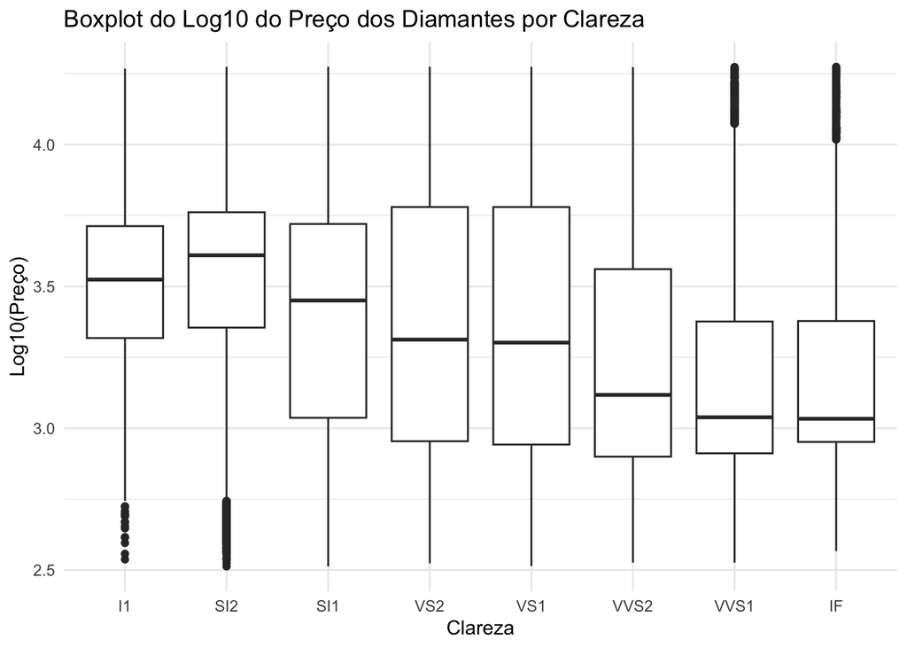

```r
# Boxplot de log10(price) por clarity
ggplot(diamonds, aes(x = clarity, y = log10(price))) +
  geom_boxplot() +
  labs(title = "Boxplot do Log10 do Preço dos Diamantes por Clareza",
       x = "Clareza",
       y = "Log10(Preço)") +
  theme_minimal()
```

**Interpretação dos padrões entre as categorias**

A transformação logarítmica dos preços reduziu a assimetria da distribuição de `price`, ao reduzir o peso dos valores extremos (outliers), tornando a distribuicão dos preços por qualidade da clareza mais próximos de uma distribuição simétrica como a normal, facilitando a comparação dos preços medianos, da variabilidade e dos outliers por categoria de clareza.

## Exercício 16

### Visualizando a Distribuição de Uma Variável Categórica

**Objetivo**: Criar um gráfico de barras para visualizar o número de respondentes por estado civil.

**Instruções**:

1. Crie uma tabela de frequência ordenada em ordem decrescente da freqüência absoluta dos estados civis (Dica: código do **slide 21**)
2. Crie um gráfico de barras horizontais básico:
3. Melhore o gráfico adicionando:
   - os valores da frequência absoluta nas barras usando `geom_text()`
   - Título e rótulos apropriados dos eixos com `labs(title = "...")`
   - Tema minimalista com `theme_minimal()`

## Solução do Exercício 16

1. Crie uma tabela de frequência ordenada em ordem decrescente da freqüência absoluta dos estados civis (Dica: código do **slide 21**)

```r
# Preparação dos dados para o gráfico

# Tabela de frequência da variável estado_civil
tabela_estadocivil <- questionario %>%
  # conta o número de respondentes por estado_civil
  count(estado_civil) %>%
  # ordena os dados pela frequência em ordem CRESCENTE (menor para maior)
  # vamos usar ordem crescente para compensar o efeito do coord_flip()
  arrange(n) %>%
  # sincroniza os niveis do factor com a ordem atual das linhas
  mutate(estado_civil = factor(estado_civil, levels = estado_civil))

# exibe a tabela (dados em ordem crescente)
tabela_estadocivil
```

```
# A tibble: 6 × 2
  estado_civil      n
  <fct>         <int>
1 Sem resposta     17
2 Separado(a)     743
3 Viúvo(a)       1807
4 Divorciado(a)  3383
5 Nunca casou    5416
6 Casado(a)     10117
```

2. Crie um gráfico de barras horizontais básico:

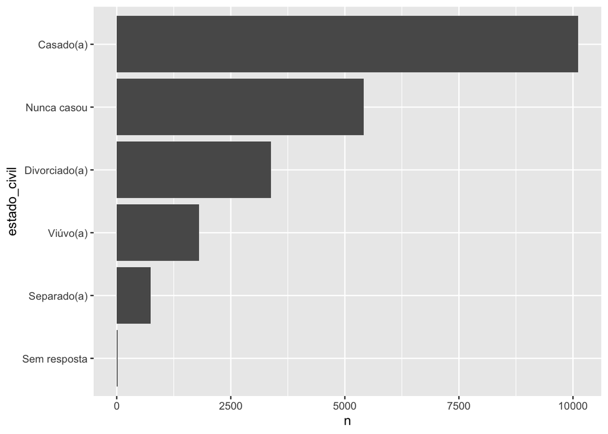

```r
ggplot(tabela_estadocivil, aes(x = estado_civil, y = n)) +
  geom_bar(stat = "identity") +
  coord_flip()
```

3. Melhore o gráfico adicionando:
   - os valores da frequência absoluta nas barras usando `geom_text()`
   - Título e rótulos apropriados dos eixos com `labs(title = "...")`
   - Tema minimalista com `theme_minimal()`

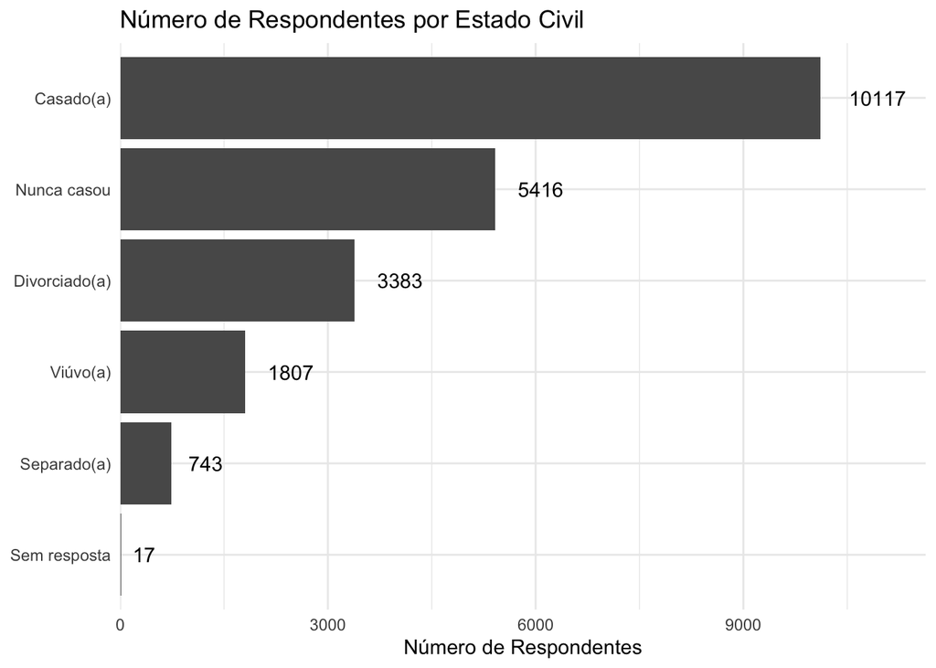

```r
# Salva o gráfico em objeto
grafico_estadocivil_freq <-
# Cria um sistema de coordenadas para o gráfico com x sendo a raça e y sendo a frequência
ggplot(tabela_estadocivil, aes(x = estado_civil, y = n)) +
  # Cria o gráfico de barras
  # stat="identity" usa os valores exatos de x = 'n' (frequência)
  geom_bar(stat="identity") +
  # Inverte os eixos
  coord_flip() +
  # geom_text() adiciona rótulos (frequência) às barras
  # hjust = -0.1: posiciona o texto um pouco à direita das barras horizontais
  geom_text(aes(label = n), hjust=-0.5) +
  # Adiciona 15% de espaço extra à direita na margem do arquivo
  # para exibir o gráfico completamente
  scale_y_continuous(expand = expansion(mult = c(0, 0.15))) +
  # Adiciona rótulos aos eixos e título do gráfico
  labs(x = NULL,
       y = "Número de Respondentes",
       title  = "Número de Respondentes por Estado Civil") +
  # Define um tema minimalista para o gráfico
  theme_minimal()

# Exibe o gráfico
grafico_estadocivil_freq
```

## Exercício 17

### Gráfico de Dispersão com Análise de Correlação

**Objetivo**: Baixar dados reais das ações da Petrobras (PETR4) e do Itaú (ITUB4) a partir do dia 2024-01-01, calcular a correlação entre elas e criar um gráfico de dispersão usando os pacotes `tidyquant`, `effectsize` e `ggplot2`.

**Instruções**:

1. Baixe os dados das duas empresas de forma compacta usando a função `tq_get()` do pacote `tidyquant`
2. Transforme os dados para análise de correlação usando `pivot_wider()`:
3. Calcule a correlação entre os preços das duas ações:
4. Interprete a magnitude da correlação usando as regras de Cohen:
5. Crie um gráfico de dispersão básico
6. Melhore o gráfico adicionando título, rótulos, reta de regressão e tema:
7. Escreva sua interpretação do gráfico de dispersão a partir do coeficiente de correlação de Pearson estimado. Pelo resultado da sua análise, se uma carteira for montada com apenas as ações da Petrobras e do Itaú, seria uma carteira diversificada de investimento em ações?

## Solução do Exercício 17

**Objetivo**: Baixar dados reais das ações da Petrobras (PETR4) e do Itaú (ITUB4) a partir do dia 2024-01-01, calcular a correlação entre elas e criar um gráfico de dispersão usando os pacotes `tidyquant`, `effectsize` e `ggplot2`.

**Instruções**:

1. Baixe os dados das duas empresas de forma compacta usando a função `tq_get()` do pacote `tidyquant`

```r
# Solução robusta e simples para baixar múltiplas séries
dados_acoes <- c("PETR4.SA", "ITUB4.SA") %>%
  tq_get(from = "2024-01-01") %>%
  select(symbol, date, close) %>%
  rename(
    empresa = symbol,
    data = date,
    preco = close
  )

# Exibe as primeiras linhas do dataframe
head(dados_acoes)
```

```
# A tibble: 6 × 3
  empresa  data       preco
  <chr>    <date>     <dbl>
1 PETR4.SA 2024-01-02  37.8
2 PETR4.SA 2024-01-03  39.0
3 PETR4.SA 2024-01-04  38.6
4 PETR4.SA 2024-01-05  38.7
5 PETR4.SA 2024-01-08  38.4
6 PETR4.SA 2024-01-09  38.1
```

2. Transforme os dados para análise de correlação usando `pivot_wider()`:

```r
dados_correlacao <- dados_acoes %>%
  pivot_wider(names_from = empresa, values_from = preco) %>%
  rename(petrobras = "PETR4.SA", itau = "ITUB4.SA")

# Exibe os dados transformados
head(dados_correlacao)
```

```
# A tibble: 6 × 3
  data       petrobras  itau
  <date>         <dbl> <dbl>
1 2024-01-02      37.8  30.5
2 2024-01-03      39.0  30.1
3 2024-01-04      38.6  29.9
4 2024-01-05      38.7  30.6
5 2024-01-08      38.4  30.3
6 2024-01-09      38.1  30.3
```

3. Calcule a correlação entre os preços das duas ações:

```r
correlacao <- cor(dados_correlacao$petrobras, dados_correlacao$itau)
round(correlacao, 3)
```

```
[1] -0.606
```

4. Interprete a magnitude da correlação usando as regras de Cohen:

```r
interpretacao <- effectsize::interpret_r(correlacao, rules = "cohen1988")
interpretacao
```

```
[1] "large"
(Rules: cohen1988)
```

5. Crie um gráfico de dispersão básico:

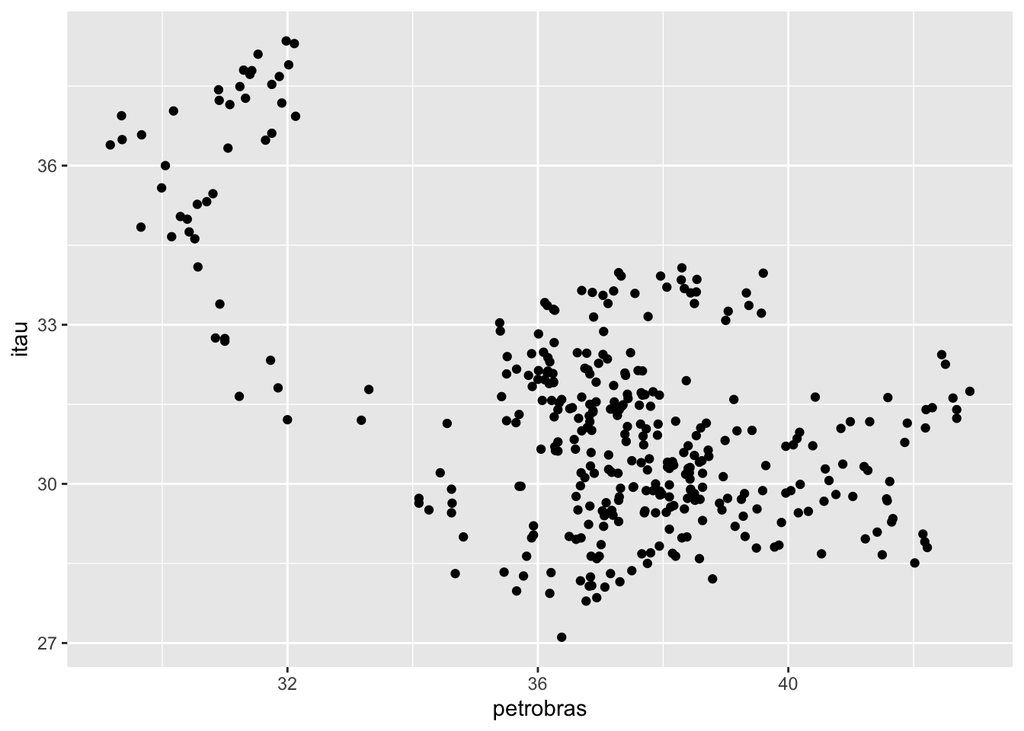

```r
ggplot(dados_correlacao, aes(x = petrobras, y = itau)) +
  geom_point()
```

6. Melhore o gráfico adicionando título, rótulos, reta de regressão e tema:

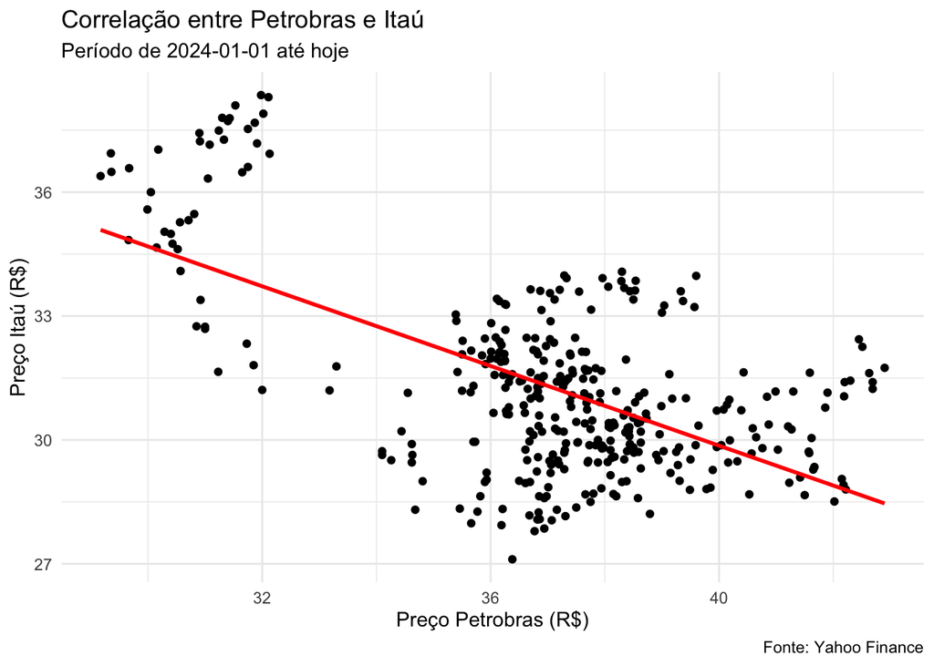

```r
# Salva o gráfico em um objeto
grafico_dispersao <-
ggplot(dados_correlacao, aes(x = petrobras, y = itau)) +
  geom_point() +
  geom_smooth(method = "lm", se = FALSE, color = "red") +
  labs(title = "Correlação entre Petrobras e Itaú",
       subtitle = "Período de 2024-01-01 até hoje",
       x = "Preço Petrobras (R$)",
       y = "Preço Itaú (R$)",
       caption = "Fonte: Yahoo Finance") +
  theme_minimal()

# Exibe o gráfico
grafico_dispersao
```

**Interpretação do gráfico de dispersão a partir do coeficiente de correlação de Pearson estimado**

O gráfico de dispersão mostra uma relação negativa entre os preços das ações da Petrobras e do Itaú, ou seja, quando o preço de uma tende a subir, o da outra tende a cair, e vice-versa. Isso é confirmado pelo coeficiente de correlação de Pearson estimado, que é negativo. Esse tipo de relação sugere que as ações se comportam de forma oposta no mercado.

Do ponto de vista de diversificação de uma carteira de investimentos, essa correlação negativa é uma característica desejável. Ao combinar ativos que se movem em direções opostas, o investidor pode reduzir o risco total da carteira, pois as perdas em um ativo podem ser compensadas por ganhos no outro. Assim, mesmo sendo apenas duas ações, a carteira formada por Petrobras e Itaú apresenta certo grau de diversificação, por causa do comportamento contrário entre elas.

Portanto, sim, com base nesse resultado, pode-se dizer que essa seria uma carteira relativamente diversificada, embora o ideal seja incluir outros ativos para aumentar ainda mais a diversificação.